# A/B/n testing: Continuous Response

Last complied on February 28, 2024

## Topics Covered

1. Review numeric and graphical summaries for experimental data with a continuous response.
2. The ANOVA model.
3. ANOVA and regression relationship.
4. ANOVA assumptions and how to check them.
5. What to do if the assumptions are violated.
6. Unequal sample sizes in ANOVA.

## Example

Many companies have already tried and tested the pattern of displaying numerical social proof in some form or another. In this experiment from Airbnb on their host signup landing page, tested two social proof statements.

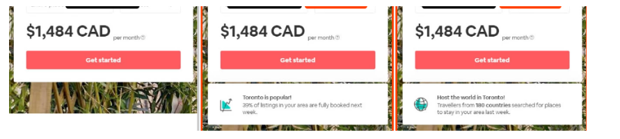

Airbnb measured sales in this experiment. The data is contained in the file “airbnb_social.csv”. Is there evidence that one treatment should be favored over another?

Summarize the data numerically and graphically.

```r
df<-read.csv("I:\\Classes\\ISA 633\\3. ABn testing\\abn testing continuous\\airbnb_social.csv")
head(df)
```

```
##   control popular   host
## 1  592.95    0.00   0.00
## 2  595.83  608.18   0.00
## 3    0.00    0.00 575.75
## 4    0.00    0.00 652.18
## 5    0.00  558.32   0.00
## 6    0.00    0.00   0.00
```

How would you describe the format of the data?

In order to analyze this data it needs to be in the *long* format. *Long* format data has a row for each observation and the column names are not variables.

```r
library(tidyverse)
df_long <- df %>% pivot_longer(everything(),
                               names_to="treatment",
                               values_to="sales")

head(df_long)
```

```
## # A tibble: 6 × 2
##   treatment sales
##   <chr>     <dbl>
## 1 control    593.
## 2 popular      0
## 3 host         0
## 4 control    596.
## 5 popular    608.
## 6 host         0
```

Make numeric summary of this data.

```r
df_long %>% group_by(treatment) %>% summarise(mean=mean(sales), sd=sd(sales), n=n())
```

```
## # A tibble: 3 × 4
##   treatment  mean    sd     n
##   <chr>     <dbl> <dbl> <int>
## 1 control    200.  284.  1200
## 2 host       201.  286.  1200
## 3 popular    207.  295.  1200
```

Make an appropriate plot of the data.

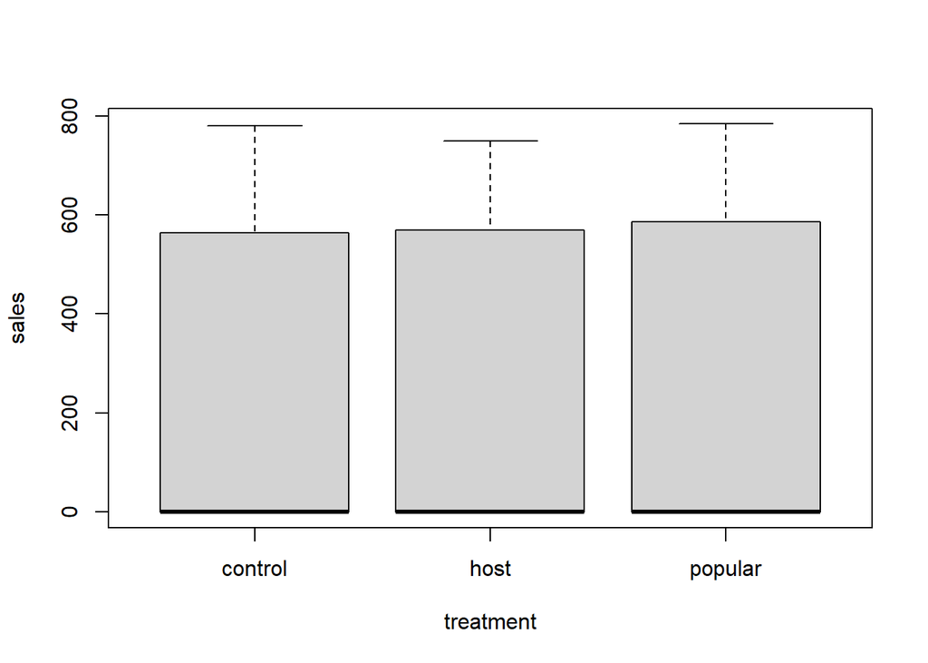

```r
boxplot(sales~treatment, data=df_long)
```

What is up with this data?

What should we do? Does it matter?

```r
nonzero<-df_long %>% filter(sales>0)
```

Let’s plot it again.

```r
nonzero %>% group_by(treatment) %>% summarise(mean=mean(sales), sd=sd(sales), n=n())
```

```
## # A tibble: 3 × 4
##   treatment  mean    sd     n
##   <chr>     <dbl> <dbl> <int>
## 1 control    600.  53.0   400
## 2 host       603.  49.9   400
## 3 popular    622.  47.6   400
```

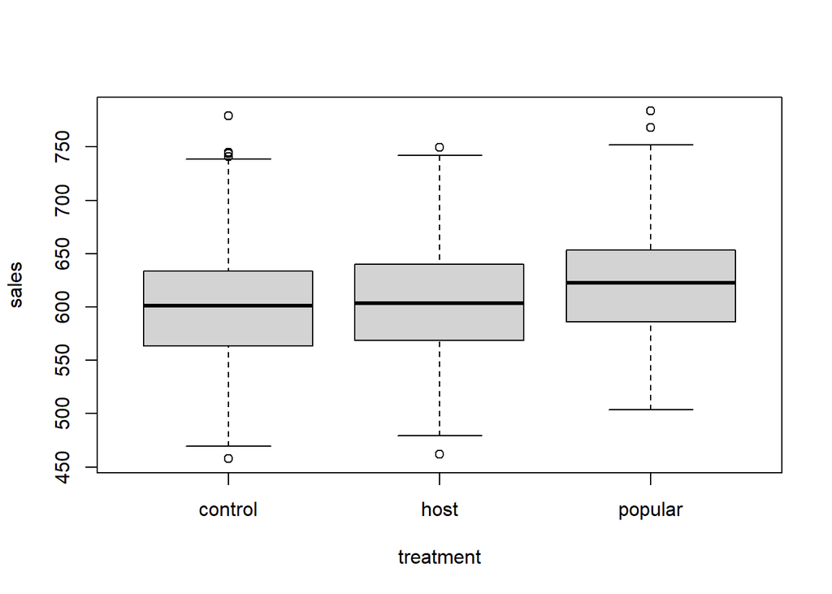

```r
boxplot(sales~treatment, data=nonzero)
```

## ANOVA

We will assume that each level of the treatment factor has different mean, $\mu_i$. The standard analysis for completely randomized designs is concerned with the structure of the means. We are trying to learn whether the means are all the same or if some differ from the others, and the nature of any differences that might be present.

The error structure is assumed to be known except for the error variance, $\sigma^2$, which must be estimated.

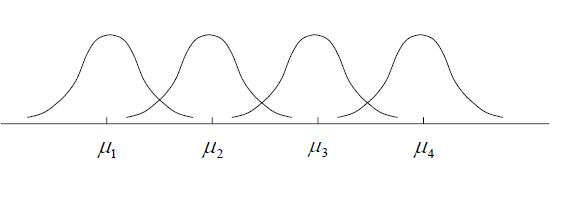

We will model our CRD with

$$Y_{ij}=\mu_i+\epsilon_{ij}$$

$Y_{ij}$=response for the $j^{th}$ experimental unit subject to the $i^{th}$ level of the treatment factor.

This is sometimes called the cell means model with a different mean, $\mu_i$, for each level of the treatment factor. The distribution of the experimental errors, $\epsilon_{ij}$, are mutually independent due to the randomization and assumed to be normally distributed.

Another way of thinking about this model is like this:

$$Y_{ij}=\mu+\tau_i+\epsilon_{ij}$$

This is the effects model. $\tau_i$ are the effects. $\tau_i$ represents the difference between the long-run average of all possible experiments at the $i^{th}$ level of the treatment factor and the overall average.

$$ssE=
\sum_{i=1}^{t}\sum_{j=1}^{r_i}(y_{ij}-\mu_i)^2$$
.

If we have included replications we can estimate the experimental error, $\sigma^2$. We estimate it using $\hat{\sigma}^2=\frac{ssE}{n-t}$.

What is a “replication”?

This error estimate is critical for determining if our treatments had a significant effect on the response.

Recall $ssE= \sum_{i=1}^{t}\sum_{j=1}^{r_i}(y_{ij}-\mu_i)^2$.

So the ssE is the variation in the response values not described by applying the treatment.

### F-test for overall effects

In our model for the completely randomized design we are interested in testing the hypotheses:

$H_0$: $\mu_1=\mu_2=...\mu_t$ or $\tau_1=\tau_2=...\tau_t$

$H_a$: at least two of the $\tau$s differ

To test these hypothesis we decompose the total sample variation in y into two parts. The part that comes from applying the treatments and the part that comes from the random error.

$$ss\text{Total}=ss\text{T}+
ssE$$

If the treatments are making a difference in the response then the variation from SST should be larger than SSE. We use a F statistic to test the ratio of these two. An ANOVA (Analysis of Variance) table represents these parts of the total variation.

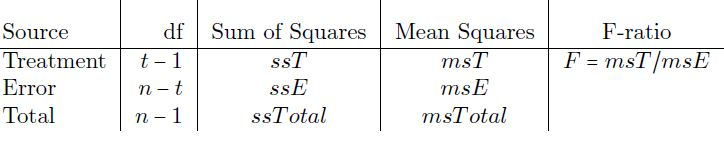

We can get those numbers using `aov`. What should we test, the nonzero data or the whole data? (this is like, your opinion, man)

```r
mod1 <- aov(sales ~ treatment, data = nonzero)
summary(mod1)
```

```
##               Df  Sum Sq Mean Sq F value   Pr(>F)
## treatment      2  115945   57973   23.02 1.55e-10 ***
## Residuals   1197 3014869    2519
## ---
## Signif. codes:  0 '***' 0.001 '**' 0.01 '*' 0.05 '.' 0.1 ' ' 1
```

## ANOVA vs. Regression

The F-test above is the same F-test that you will get out of `lm`.

```r
reg<-lm(aov(sales ~ treatment, data = nonzero))
summary(reg)
```

```
##
## Call:
## lm(formula = aov(sales ~ treatment, data = nonzero))
##
## Residuals:
##      Min       1Q   Median       3Q      Max
## -142.009  -35.943    0.904   34.312  179.671
##
## Coefficients:
##                  Estimate Std. Error t value Pr(>|t|)
## (Intercept)       599.769      2.509 239.016  < 2e-16 ***
## treatmenthost       2.925      3.549   0.824     0.41
## treatmentpopular   22.160      3.549   6.244  5.9e-10 ***
## ---
## Signif. codes:  0 '***' 0.001 '**' 0.01 '*' 0.05 '.' 0.1 ' ' 1
##
## Residual standard error: 50.19 on 1197 degrees of freedom
## Multiple R-squared:  0.03703,    Adjusted R-squared:  0.03542
## F-statistic: 23.02 on 2 and 1197 DF,  p-value: 1.553e-10
```

So why are we using ANOVA here?

What does the coefficient from that model for “treatmenthost” mean?

Is that what we want to know?

The ANOVA gives us what we want to know. Regression gives us an analysis, which is not necessarily incorrect, but it does not answer the question that we want.

In this case, because the number of samples in each group are the same:

```r
nonzero %>% group_by(treatment) %>% summarise(mean=mean(sales), sd=sd(sales), n=n())
```

```
## # A tibble: 3 × 4
##   treatment  mean    sd     n
##   <chr>     <dbl> <dbl> <int>
## 1 control    600.  53.0   400
## 2 host       603.  49.9   400
## 3 popular    622.  47.6   400
```

The predicted values from the regression and the predicted values from the ANOVA models will be the same:

```r
unique(mod1$fitted.values)
```

```
## [1] 599.7685 599.7685 621.9282 602.6933 621.9282 599.7685 621.9282
```

```r
unique(reg$fitted.values)
```

```
## [1] 599.7685 599.7685 621.9282 602.6933 621.9282 599.7685 621.9282
```

Ok, so there are only three predicted values?? What are they?

```r
mean(nonzero$sales[nonzero$treatment=="control"])
```

```
## [1] 599.7685
```

```r
mean(nonzero$sales[nonzero$treatment=="host"])
```

```
## [1] 602.6933
```

```r
mean(nonzero$sales[nonzero$treatment=="popular"])
```

```
## [1] 621.9282
```

## ANOVA Assumptions

CAUTION: Even an OU student can figure out the code to analyze a CRD in R. But just because R gives you output does not imply that output is valid.

In order for the above analysis to be valid, we are assuming that ssE represents *replicate* experimental units. There is no substitution for a replicate.

Recall we check the assumptions by plotting the residuals. In this case the residuals are the differences in the responses $y_{ij}$ and the treatment means $\hat{\mu}_i$.

We should view:

1. A scatter plot of the residuals vs. the factor levels to check to see if the variance is constant across the various treatments.
2. A graph of the residuals vs. the predicted values (or treatment means) can show us if the variance is increasing as the mean level of the response increases.
3. A scatter plot of the residuals vs the experimental unit numbers can reveal inadequacies in randomization (violation of the independence assumption).
4. A normal probability plot of the residuals will help us check if the residuals are normally distributed.

Here is some nice code (you can use all the time and adjust accordingly).

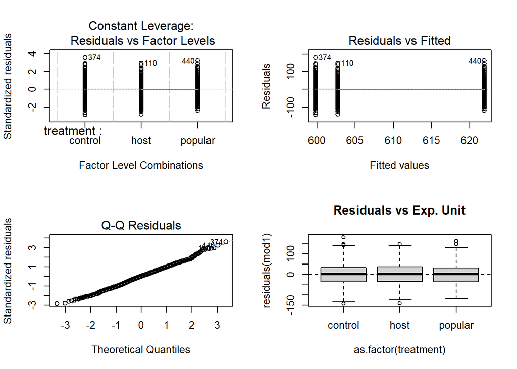

```r
par( mfrow = c(2,2) )
plot(mod1, which=5)
plot(mod1, which=1)
plot(mod1, which=2)
plot(residuals(mod1) ~ as.factor(treatment), main="Residuals vs Exp. Unit", font.main=1,data=nonzero)
abline(h = 0, lty = 2)
```

### What if Assumptions are violated?

Scrap the entire experiment and quit your job. NO! We can use some strategic transformations to get our residuals to look how they are supposed to.

Transforming the response adjusts the response so it is line with our assumptions.

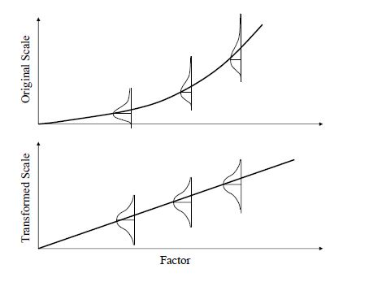

A transformed response will typically result in a more sensitive analysis (i.e. more likely to detect the treatment effect).

A popular type of transformation is a Box-Cox power transformation where $Y=y^\lambda$. If the variance tends to increase as the mean increases choose a value of $\lambda$ less than one. If the variance tends to decrease then choose a value of $\lambda$ greater than 1.

A common situation is when the response is actually a measure of variability.

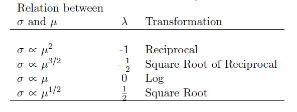

In a CRD with replicates in each level of the treatment factor a way to determine the best value of $\lambda$ is to find the maximum of the log-likelihood function. The value of $\lambda$ that maximizes the log-likelihood or minimizes the ssE is the value chosen.

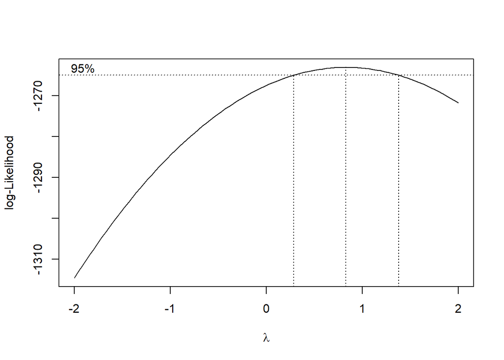

```r
library(MASS)
bc<-boxcox(mod1)
```

```r
lambda<-bc$x[which.max(bc$y)]
lambda
```

```
## [1] 0.8282828
```

Then we can apply the transformation, although this is not necessary for our AirBnb example.

```r
t_nonzero<- transform(nonzero, t_sales = sales^(0.8282828))
mod2 <- aov(t_sales ~ treatment, data = t_nonzero)
summary(mod2)
```

```
##               Df Sum Sq Mean Sq F value   Pr(>F)
## treatment      2   8846    4423   23.12 1.41e-10 ***
## Residuals   1197 229037     191
## ---
## Signif. codes:  0 '***' 0.001 '**' 0.01 '*' 0.05 '.' 0.1 ' ' 1
```

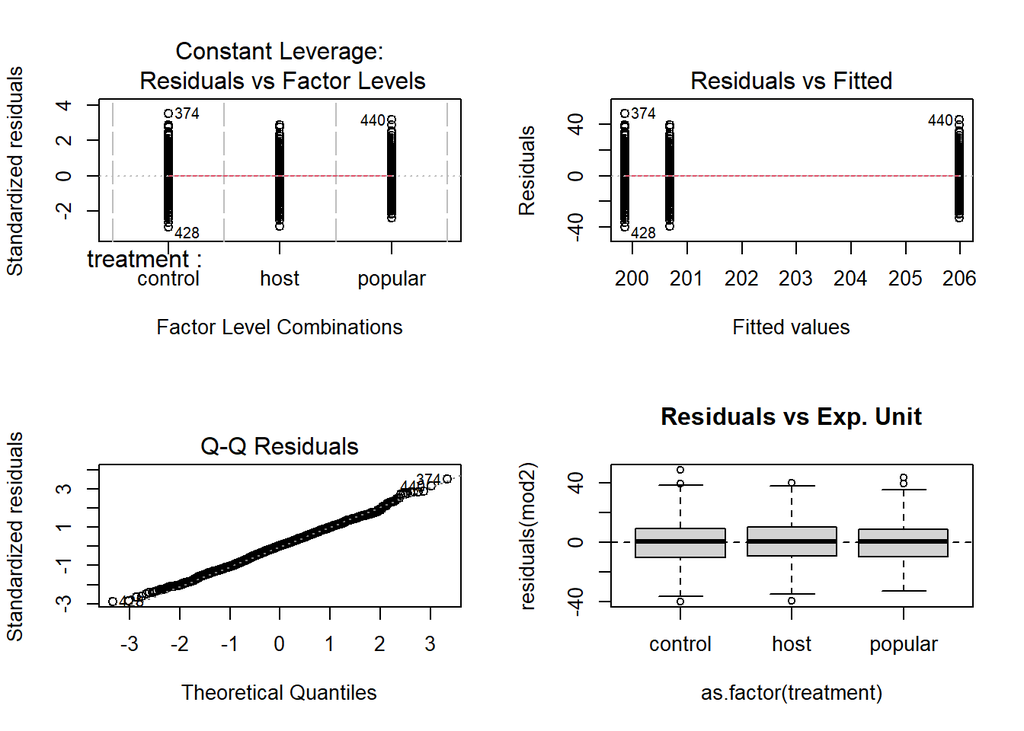

```r
par( mfrow = c(2,2) )
plot(mod2, which=5)
plot(mod2, which=1)
plot(mod2, which=2)
plot(residuals(mod2) ~ as.factor(treatment), main="Residuals vs Exp. Unit", font.main=1,data=t_nonzero)
abline(h = 0, lty = 2)
```

## ANOVA when Sample Sizes are Different

If the sample sizes are unequal then there is bias created and the result will differ depending upon the order the data is analyzed. Essentially those numbers will not be equal to the sample means.

The solution is to use an alternative type of sums of squares, Type III sums of squares. Type III sums of square use the least squares estimate for the mean values (which as we saw when the sample sizes are equal is equal to the sample mean) instead of the sample mean.

```r
library(car)
Anova(lm(sales~treatment, data=nonzero), type="III")
```

```
## Anova Table (Type III tests)
##
## Response: sales
##                Sum Sq   Df   F value    Pr(>F)
## (Intercept) 143888913    1 57128.526 < 2.2e-16 ***
## treatment      115945    2    23.017 1.553e-10 ***
## Residuals     3014869 1197
## ---
## Signif. codes:  0 '***' 0.001 '**' 0.01 '*' 0.05 '.' 0.1 ' ' 1
```

Now I will unbalance the data.

```r
un_nonzero<-nonzero[-c(1000:1200),]
un_nonzero %>% group_by(treatment) %>% summarise(mean=mean(sales), sd=sd(sales), n=n())
```

```
## # A tibble: 3 × 4
##   treatment  mean    sd     n
##   <chr>     <dbl> <dbl> <int>
## 1 control    600.  53.0   332
## 2 host       604.  49.1   328
## 3 popular    622.  46.7   339
```

And use the Type III sums of squares.

```r
Anova(lm(sales~treatment, data=un_nonzero), type="III")
```

```
## Anova Table (Type III tests)
##
## Response: sales
##                Sum Sq  Df   F value    Pr(>F)
## (Intercept) 119627604   1 48579.766 < 2.2e-16 ***
## treatment       88245   2    17.918 2.265e-08 ***
## Residuals     2452649 996
## ---
## Signif. codes:  0 '***' 0.001 '**' 0.01 '*' 0.05 '.' 0.1 ' ' 1
```

And here is what happens with the standard ANOVA.

```r
mod<-aov(sales~treatment, data=un_nonzero)
mod
```

```
## Call:
##    aov(formula = sales ~ treatment, data = un_nonzero)
##
## Terms:
##                 treatment Residuals
## Sum of Squares    88244.9 2452648.6
## Deg. of Freedom         2       996
##
## Residual standard error: 49.62357
## Estimated effects may be unbalanced
```

```r
summary(mod)
```

```
##              Df  Sum Sq Mean Sq F value   Pr(>F)
## treatment     2   88245   44122   17.92 2.27e-08 ***
## Residuals   996 2452649    2462
## ---
## Signif. codes:  0 '***' 0.001 '**' 0.01 '*' 0.05 '.' 0.1 ' ' 1
```

If the sample sizes are relatively close then the conclusion will probably not matter. But if the sample sizes are really different then a check with the Type III sums of square might be warranted, particularly if the p-value is larger.

## Python Code

```r
library(reticulate)
#py_install("plotnine")
```

```python
import pandas as pd

df = pd.read_csv("I:\\Classes\\ISA 633\\3. ABn testing\\abn testing continuous\\airbnb_social.csv")

print(df.head())
```

```
##    control  popular    host
## 0   592.95     0.00    0.00
## 1   595.83   608.18    0.00
## 2     0.00     0.00  575.75
## 3     0.00     0.00  652.18
## 4     0.00   558.32    0.00
```

```python
df_long = pd.melt(df, var_name='treatment', value_name='sales')

print(df_long.head())
```

```
##   treatment   sales
## 0   control  592.95
## 1   control  595.83
## 2   control    0.00
## 3   control    0.00
## 4   control    0.00
```

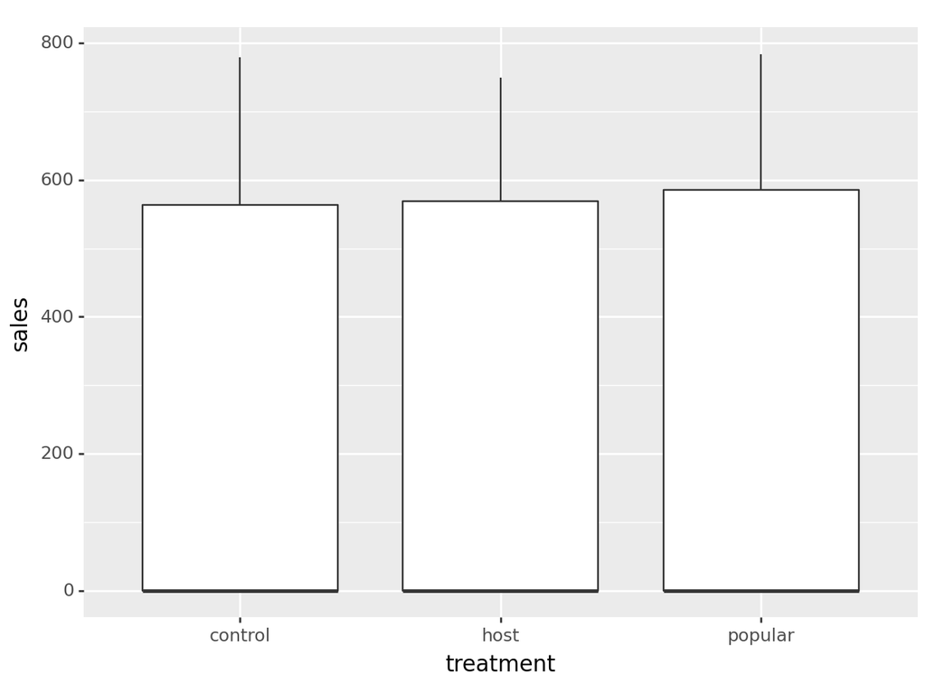

```python
from plotnine import ggplot, aes, geom_boxplot, theme, theme_bw

plot = ggplot(df_long, aes(x='treatment', y='sales')) + geom_boxplot()

print(plot)
```

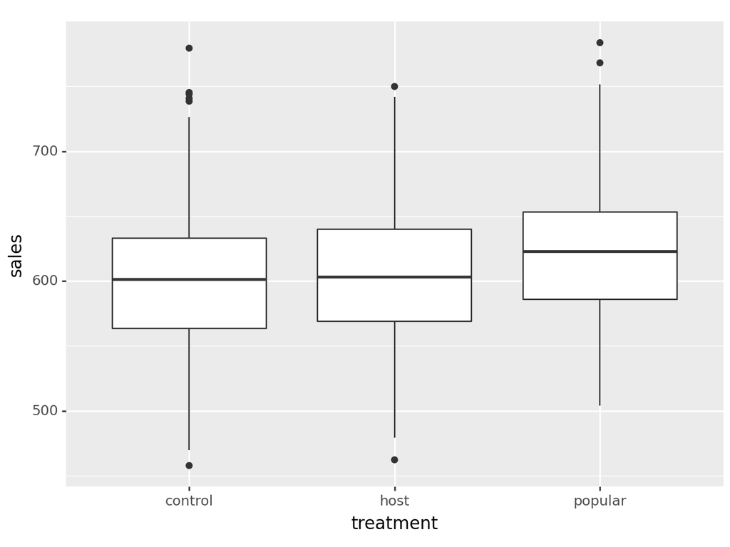

```python
nonzero = df_long[df_long['sales'] > 0]

plot = ggplot(nonzero, aes(x='treatment', y='sales')) + geom_boxplot()

print(plot)
```

```python
import statsmodels.api as sm
from statsmodels.formula.api import ols

# Performing ANOVA
mod1 = ols('sales ~ treatment', data=nonzero).fit()
anova_results = sm.stats.anova_lm(mod1)

# Displaying the summary of the ANOVA
print(anova_results)
```

```
##                df        sum_sq       mean_sq          F        PR(>F)
## treatment     2.0  1.159450e+05  57972.513228  23.016952  1.553420e-10
## Residual   1197.0  3.014869e+06   2518.687649        NaN           NaN
```

```python
import statsmodels.api as sm
import statsmodels.formula.api as smf
import pandas as pd

# Performing linear regression
model = smf.ols('sales ~ treatment', data=nonzero).fit()

# Displaying the summary of the regression
print(model.summary())
```

```
##                             OLS Regression Results
## ==============================================================================
## Dep. Variable:                  sales   R-squared:                       0.037
## Model:                            OLS   Adj. R-squared:                  0.035
## Method:                 Least Squares   F-statistic:                     23.02
## Date:                Wed, 28 Feb 2024   Prob (F-statistic):           1.55e-10
## Time:                        12:06:07   Log-Likelihood:                -6400.1
## No. Observations:                1200   AIC:                         1.281e+04
## Df Residuals:                    1197   BIC:                         1.282e+04
## Df Model:                           2
## Covariance Type:            nonrobust
## ========================================================================================
##                            coef    std err          t      P>|t|      [0.025      0.975]
## ----------------------------------------------------------------------------------------
## Intercept              599.7685      2.509    239.016      0.000     594.845     604.692
## treatment[T.host]        2.9247      3.549      0.824      0.410      -4.038       9.887
## treatment[T.popular]    22.1597      3.549      6.244      0.000      15.197      29.122
## ==============================================================================
## Omnibus:                        1.071   Durbin-Watson:                   1.966
## Prob(Omnibus):                  0.585   Jarque-Bera (JB):                1.084
## Skew:                           0.073   Prob(JB):                        0.582
## Kurtosis:                       2.977   Cond. No.                         3.73
## ==============================================================================
##
## Notes:
## [1] Standard Errors assume that the covariance matrix of the errors is correctly specified.
```

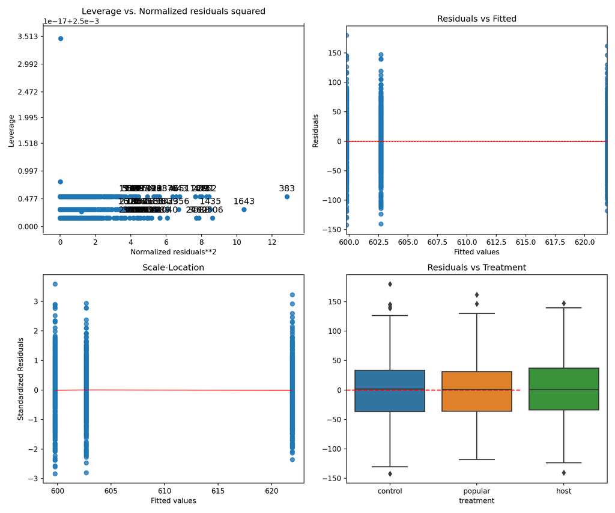

```python
import matplotlib.pyplot as plt
import seaborn as sns
import pandas as pd



# Create a 2x2 subplot
fig, axs = plt.subplots(2, 2, figsize=(12, 10))

# Plot 1: Residuals vs Leverage
sm.graphics.plot_leverage_resid2(model, ax=axs[0, 0])

# Plot 2: Residuals vs Fitted
sns.residplot(x=model.fittedvalues, y=model.resid, lowess=True, ax=axs[0, 1],
              line_kws={'color': 'red', 'lw': 1})
axs[0, 1].set_title('Residuals vs Fitted')
axs[0, 1].set_xlabel('Fitted values')
axs[0, 1].set_ylabel('Residuals')

# Plot 3: Scale-Location
sns.regplot(x=model.fittedvalues, y=model.resid_pearson, scatter=True,
            ci=False, lowess=True, ax=axs[1, 0], line_kws={'color': 'red', 'lw': 1})
axs[1, 0].set_title('Scale-Location')
axs[1, 0].set_xlabel('Fitted values')
axs[1, 0].set_ylabel('Standardized Residuals')

# Plot 4: Residuals vs Treatment
sns.boxplot(x='treatment', y=model.resid, data=nonzero, ax=axs[1, 1])
axs[1, 1].set_title('Residuals vs Treatment')
axs[1, 1].hlines(0, xmin=-0.5, xmax=1.5, colors='red', linestyles='dashed')

plt.tight_layout()
plt.show()
```

```python
# Fit the model
model = smf.ols('sales ~ treatment', data=nonzero).fit()

# Perform Type III ANOVA
anova_results = sm.stats.anova_lm(model, typ=3)

# Display the ANOVA table
print(anova_results)
```

```
##                  sum_sq      df             F        PR(>F)
## Intercept  1.438889e+08     1.0  57128.526237  0.000000e+00
## treatment  1.159450e+05     2.0     23.016952  1.553420e-10
## Residual   3.014869e+06  1197.0           NaN           NaN
```